# Act_report

### After gathering, assessing and cleaning our data. The result are, two dataframes 'image_prediction_master.csv' and 'twitter_archive_master.csv'. The two dataframes where then joined to form 'tweet_predictions'

### Insight 1:

#### Given our dataset and it's current outliers, the average score rating is 13.21/10.The distribution of ratings can be said to range from 0 for the minimum value to a maximum value of 1776: These values are assumed to be incorrect, as all scores given by @dog_rates have thier numerator greater than 10. so zero is most probable an impossible minimum score value and also 1776 is also an improbable score rating as @dog_rates rating numerator often range from 10 to 20. Given the outliers are out of range the same goes fro the avearge score rating whose value greatly depend on its outliers.

### Insight 2:

#### They are seven categories of dog_stages from our data, these stages include: doggo, doggofloofer, doggopupper, doggopuppo, floofer, pupper, and puppo. Ordered from the most populated to the least populated.

#### 1. pupper is the most populated with a count of 224

#### 2. doggo is the second in number with 75.

#### 3. puppo is third with 24 counts.

#### 4. doggopupper is fourth with 10 counts.

#### 5. foofer is fifth with 9 counts.

#### 6. doggopuppo and doggofloofer all have a count of 1.

#### There seems to be a data quality issue with our data as they are so many missing data in dog_stage column and they also seem to be incorrect data type, these data types include: doggofloofer, doggopupper, doggopuppo. These issues make our results drift further from our actual truth.

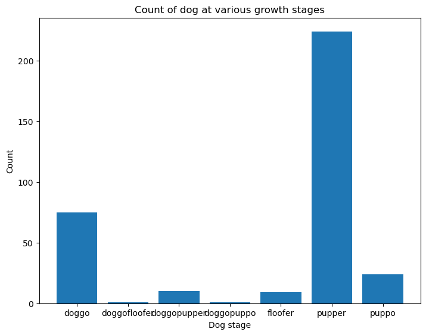

### Insight 3:

#### The tweet with highest number of favorite counts was tweeted on 2017-01-21. There isn't muuch to say about this insight but one can see from the text that the dog_stage was a puppo and the tweet came from an iphone user.